# The QIF Layer Architecture

Why the Next Generation of Brain-Computer Interfaces Needs Quantum-Aware Protection

Author

Qinnovate LLC, with Claude (Anthropic)

Published

February 2, 2026

## 1 Why OSI Failed

The OSI model was designed in 1984 for packet-switched telecommunications. Its 7 layers — Physical, Data Link, Network, Transport, Session, Presentation, Application — describe how a byte moves between computers. A brain-computer interface is not a packet-switched network. There is no MAC addressing at the electrode-tissue boundary. There is no IP routing in the cortex. TCP flow control does not apply to neural oscillations.

QIF v2.0 stacked 7 neural layers on top of 7 OSI layers, creating a 14-layer tower. This was a metaphor, not a model. It implied the neural domain sits “above” silicon in some processing hierarchy. In reality, the electrode-tissue interface is where silicon and biology *physically touch* — they are adjacent, not stacked.

**QIF v3.0 removes all OSI heritage.** The layer model is now derived entirely from neuroscience and quantum physics.

## 2 The Hourglass

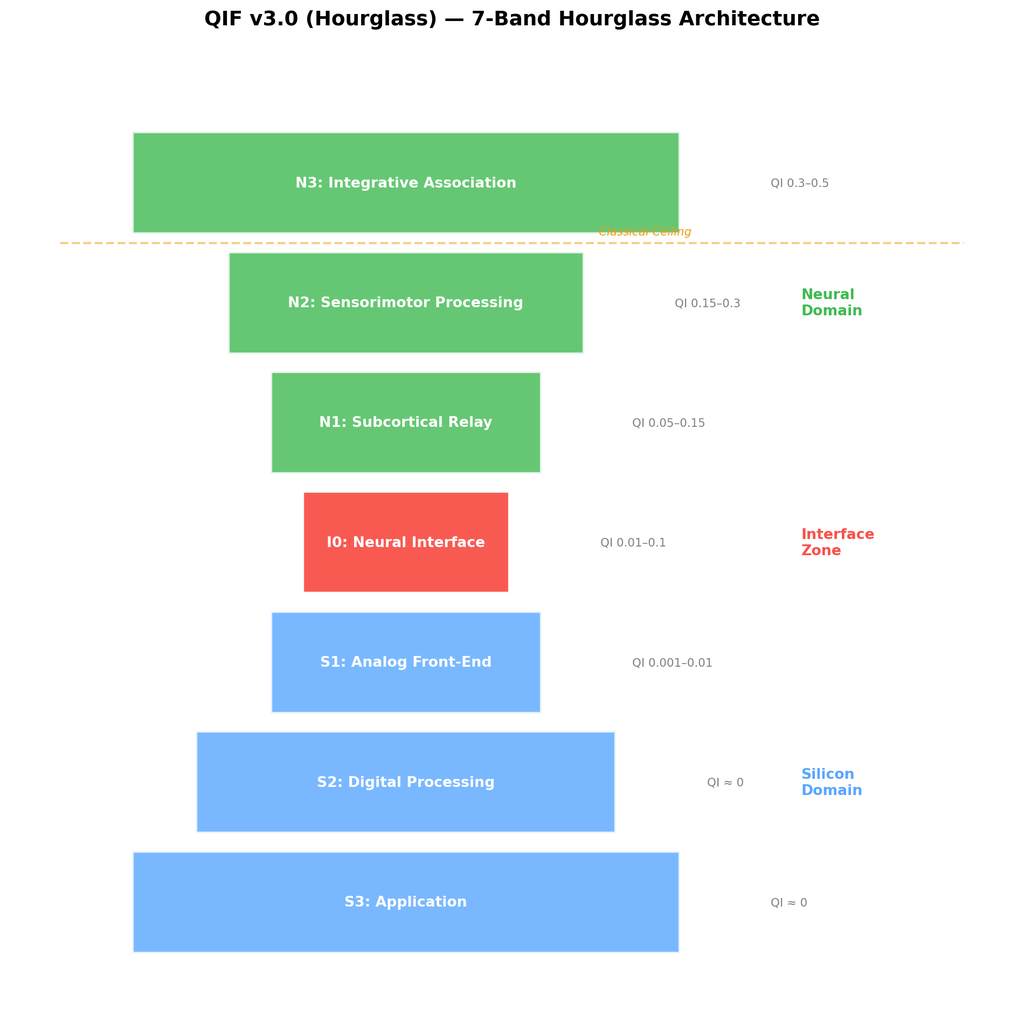

Figure 1: QIF v3.0 — 7-Band Hourglass Architecture (3-1-3 symmetric). Width represents state space / possibility space. Narrowest at I0 (measurement collapses possibilities). The classical ceiling separates chaotic (N2) from quantum uncertain (N3).

## 3 The 7 Bands

Table 1: QIF v3.0 — 7-Band Hourglass Architecture (3-1-3 symmetric)

|  | Band | Name | Zone | Determinacy | QI Range | Brain Regions |
| --- | --- | --- | --- | --- | --- | --- |
| 0 | N3 | Integrative Association | Neural Domain | Quantum Uncertain | 0.3–0.5 | PFC, ACC, Broca, Wernicke, HIPP, BLA, insula |
| 1 | N2 | Sensorimotor Processing | Neural Domain | Chaotic → Stochastic | 0.15–0.3 | M1, S1_cortex, V1, A1, PMC, SMA, PPC, cerebellum |
| 2 | N1 | Subcortical Relay | Neural Domain | Stochastic | 0.05–0.15 | thalamus, basal ganglia, cerebellum, brainstem... |
| 3 | I0 | Neural Interface | Interface Zone | Quasi-quantum (ΓD ∈ (0,1)) | 0.01–0.1 | — |
| 4 | S1 | Analog Front-End | Silicon Domain | Stochastic (analog noise) | 0.001–0.01 | — |
| 5 | S2 | Digital Processing | Silicon Domain | Deterministic | ≈ 0 | — |
| 6 | S3 | Application | Silicon Domain | Deterministic | ≈ 0 | — |

### 3.1 Hourglass Geometry

- **Width = state space / possibility space.** At any horizontal slice of the hourglass, width represents how many states the system could occupy.
- **Widest at N3** — integrative association cortex, maximum security-relevant indeterminacy.
- **Widest at S3** — maximum classical pathways, full deterministic branching.
- **Narrowest at I0** — measurement collapses possibilities. All information must pass through this bottleneck.
- **3-1-3 symmetry** — 3 neural bands, 1 interface band, 3 silicon bands. The hourglass is structurally balanced.
- **The bottleneck has real thickness** — the quasi-quantum zone is not a line but a band where partial decoherence has occurred (0 < ΓD < 1).

### 3.2 Naming Convention

- Format: `{Zone}{Number}` — N3, N2, N1, I0, S1, S2, S3
- Numbers increase **away from the interface** in both directions
- No relation to OSI layer numbers

## 4 The Classical Ceiling

The boundary between N2 (chaotic) and N3 (quantum uncertain) is the **classical ceiling** — the dividing line between two fundamentally different kinds of unpredictability:

Table 2: Determinacy Spectrum — 4 levels mapped to QIF bands

|  | Level | Bands | Description |
| --- | --- | --- | --- |
| 0 | Deterministic | S2, S3 | f(state,t) → next_state, no randomness |
| 1 | Stochastic | S1, N1 | Known probability distributions, epistemic ran... |
| 2 | Chaotic | N2 | Deterministic but sensitive to initial conditi... |
| 3 | Quantum Uncertain | N3 | Heisenberg-bounded, security-relevant indeterm... |

**Below the ceiling** (deterministic, stochastic, chaotic): all unpredictability is — in principle — resolvable with better measurement. Hidden variables exist (Bell’s theorem does not apply). Classical security tools operate here.

**Above the ceiling** (quantum uncertain): unpredictability is *ontic* — a property of reality, not of our knowledge. No amount of measurement can eliminate it. QIF’s quantum terms are essential here.

## 5 Brain Region Dependency Graph

Brain regions don’t form a linear chain — they form a directed graph with parallel pathways, convergence hubs, and feedback loops.

Table 3: Brain regions mapped to QIF bands with connections

|  | Region | Band | Connections |
| --- | --- | --- | --- |
| 0 | PFC | N3 | Broca, Wernicke, HIPP, BLA, insula, M1, PMC, S... |
| 1 | ACC | N3 | PFC, BLA, insula, brainstem |
| 2 | Broca | N3 | Wernicke, PFC |
| 3 | Wernicke | N3 | A1, Broca, PFC |
| 4 | HIPP | N3 | BLA, thalamus, PFC |
| 5 | BLA | N3 | HIPP, PFC, insula, CeA |
| 6 | insula | N3 | ACC, BLA, PFC, S1_cortex |
| 7 | M1 | N2 | PFC, PMC, SMA, basal ganglia, cerebellum |
| 8 | S1_cortex | N2 | thalamus, PFC, insula |
| 9 | V1 | N2 | thalamus, PPC |
| 10 | A1 | N2 | thalamus, Wernicke |
| 11 | PMC | N2 | PFC, M1 |
| 12 | SMA | N2 | PFC, M1 |
| 13 | PPC | N2 | V1, M1, PMC, PFC |
| 14 | cerebellum | N1/N2 | M1, thalamus, PFC, PMC |
| 15 | thalamus | N1 | V1, A1, S1_cortex, PFC, HIPP |
| 16 | basal ganglia | N1 | M1, PFC, thalamus |
| 17 | brainstem | N1 | thalamus, cerebellum, PFC, CeA, ACC |
| 18 | CeA | N1 | BLA, brainstem, thalamus |

Key structural properties:

- **Parallel pathways**: V1, A1, S1_cortex operate simultaneously (visual, auditory, somatosensory)
- **Convergence hub**: PFC receives input from nearly every region — the integration point
- **Mandatory gateway**: Thalamus gates almost all sensory input to cortex
- **Feedback**: PFC sends signals back to sensory and subcortical regions (attention, modulation)
- **Salience network**: Insula and ACC detect behaviorally relevant stimuli, bridging bodily sensation to conscious awareness
- **Amygdala split**: BLA (basolateral, N3) handles associative learning; CeA (central, N1) drives autonomic output
- **Cerebellar spanning**: Cerebellum bridges N1 relay and N2 sensorimotor via cerebellar-cortical loops

## 6 I0: The Most Critical Band

I0 (Neural Interface) is where silicon meets biology — the measurement bottleneck. This is:

- Where quantum neural states collapse into classical data (recording)
- Where classical commands enter the quantum neural domain (stimulation)
- The attack surface for quantum-level threats (tunneling exploits, soliton attacks)
- Where the QI equation operates most directly

No existing framework addresses this boundary at the quantum level. The hourglass geometry makes its centrality visible: all information must pass through I0.

## 7 QI Gradient

QI increases monotonically from S3 (zero) through I0 to N3 (maximum ~0.5). This follows from physics:

1. **Lower bands involve more particles** — quantum effects average out (decoherence)
2. **Higher bands have longer integration times** — more quantum phase space is sampled
3. **The decoherence factor ΓD maps to band position** — lower bands are fully decohered, upper bands retain partial coherence

The layers where QI is highest are the layers where compromise is most catastrophic — and where classical security offers the least protection.

## 8 v2.0 → v3.0 Migration

Table 4: Migration from deprecated v2.0 (14-layer) to v3.0 (7-band hourglass)

|  | v2.0 | v3.0 |
| --- | --- | --- |
| 0 | L1 | S3 |
| 1 | L2 | S3 |
| 2 | L3 | S3 |
| 3 | L4 | S3 |
| 4 | L5 | S3 |
| 5 | L6 | S3 |
| 6 | L7 | S3 |
| 7 | L8 | I0 |
| 8 | L9 | I0/N1 |
| 9 | L10 | N1/N2 |
| 10 | L11 | N2 |
| 11 | L12 | N3 |
| 12 | L13 | N3 |
| 13 | L14 | N3 |